# Educational Attainment and 2024 Presidential Voting Patterns

A State-Level Analysis | Generated: 2026-05-29 15:16:32

### Executive Summary

- Strong positive correlation between education and Democratic vote share: *r* = 0.754 (*p* < 0.001)
- 56.9% of variance in voting patterns explained by education levels
- States won by Democrats have 8.3 percentage points higher average educational attainment (*p* < 0.001)
- All top 10 most educated states voted Democratic
- 9 of 10 least educated states voted Republican

## Data Sources

**Educational Attainment:** U.S. Census Bureau (via Business Insider analysis), May 28, 2026

**2024 Presidential Election:** Official certified results, Harris vs. Trump

## Statistical Analysis

### Correlation Analysis

The analysis reveals a **strong positive correlation** between educational attainment and Democratic vote share:

- **Pearson correlation coefficient:** *r* = 0.7544 (*p* = 2.51e-10)
- **Spearman rank correlation:** *ρ* = 0.7715 (*p* = 5.49e-11)

Both correlations are statistically significant at *p* < 0.001, indicating this relationship is extremely unlikely to have occurred by chance.

### Regression Model

Linear regression modeling Democratic vote share as a function of bachelor's degree attainment:

**Model:** Democratic Vote % = -2.98 + 1.36 × Education %  
**R²:** 0.5691 (explains 56.91% of variance)  
**Slope:** 1.3577 ± 0.1705 (standard error)  
**p-value:** 2.51e-10

**Interpretation:** For each 1 percentage point increase in bachelor's degree attainment, Democratic vote share increases by 1.36 percentage points on average.

### Group Comparison

| Group | N | Mean Education (%) | Std Dev | Range |
| --- | --- | --- | --- | --- |
| Democratic-won states | 19 | 40.88 | 4.16 | 31.8-48.3 |
| Republican-won states | 29 | 32.58 | 3.61 | 24.4-39.1 |
| Difference | — | 8.30 | — | — |

**Independent t-test:** *t* = 7.3354, *p* = 2.87e-09

The mean educational attainment difference of 8.30 percentage points between Democratic-won and Republican-won states is highly statistically significant.

## Visualizations

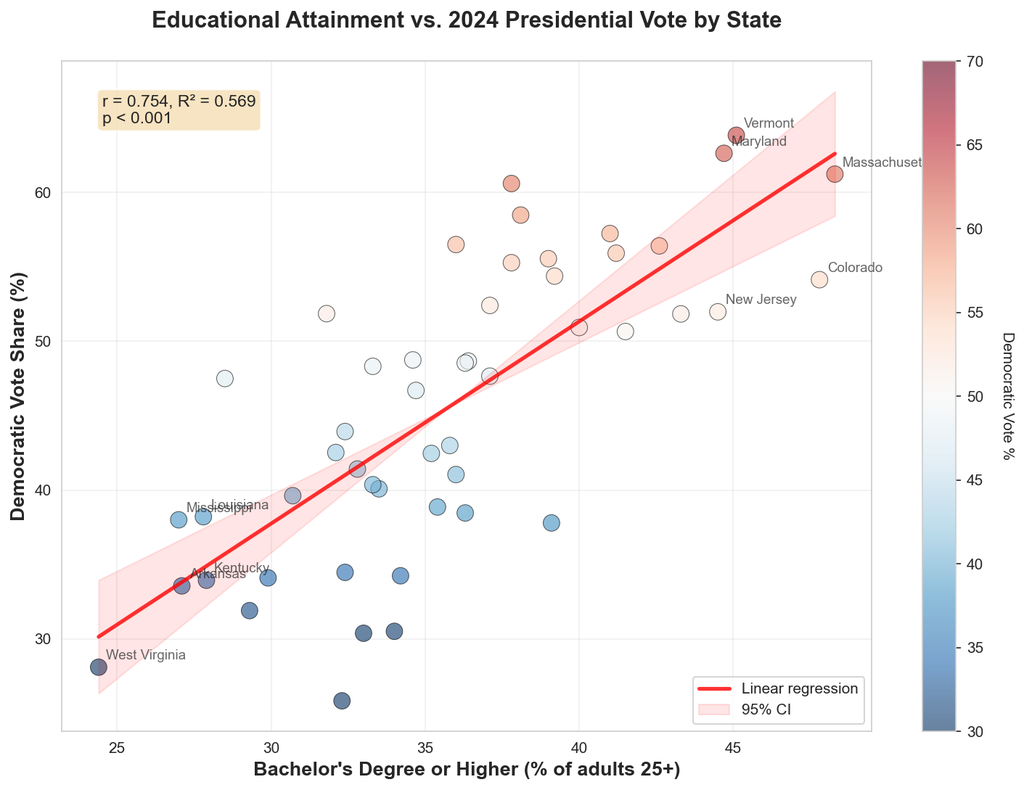

Figure 1: Relationship between educational attainment and 2024 Democratic vote share

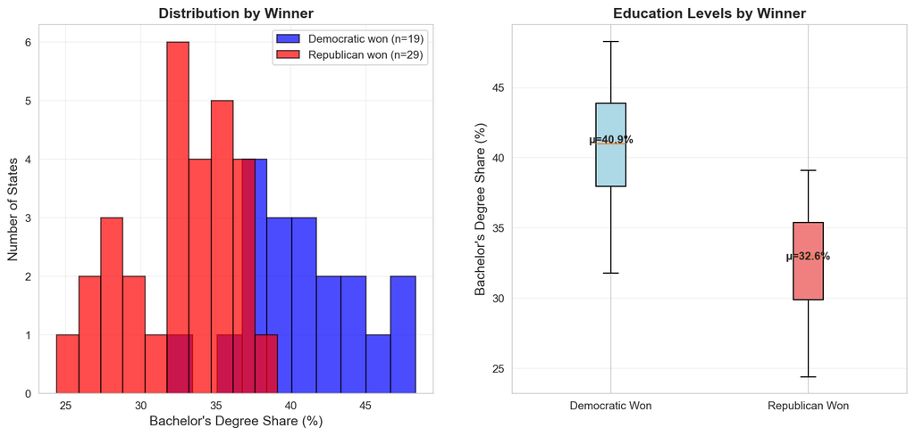

Figure 2: Distribution of educational attainment by election winner

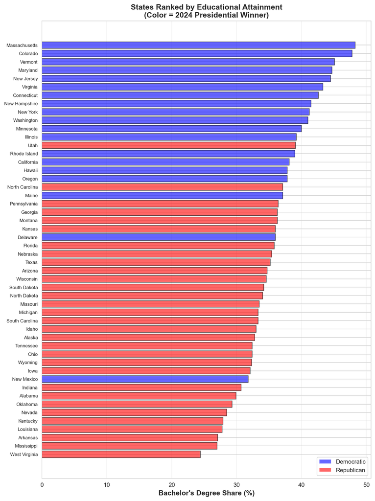

## State Rankings

### Top 10 Most Educated States

| Rank | State | Education (%) | Dem Vote (%) | Rep Vote (%) | Winner |
| --- | --- | --- | --- | --- | --- |
| 1 | Massachusetts | 48.3 | 61.2 | 36.0 | Democratic |
| 2 | Colorado | 47.8 | 54.1 | 43.1 | Democratic |
| 3 | Vermont | 45.1 | 63.8 | 32.3 | Democratic |
| 4 | Maryland | 44.7 | 62.6 | 34.1 | Democratic |
| 5 | New Jersey | 44.5 | 52.0 | 46.1 | Democratic |
| 6 | Virginia | 43.3 | 51.8 | 46.0 | Democratic |
| 7 | Connecticut | 42.6 | 56.4 | 41.9 | Democratic |
| 8 | New Hampshire | 41.5 | 50.6 | 47.9 | Democratic |
| 9 | New York | 41.2 | 55.9 | 43.3 | Democratic |
| 10 | Washington | 41.0 | 57.2 | 39.0 | Democratic |

### Bottom 10 Least Educated States

| Rank | State | Education (%) | Dem Vote (%) | Rep Vote (%) | Winner |
| --- | --- | --- | --- | --- | --- |
| 1 | West Virginia | 24.4 | 28.1 | 70.0 | Republican |
| 2 | Mississippi | 27.0 | 38.0 | 60.9 | Republican |
| 3 | Arkansas | 27.1 | 33.6 | 64.2 | Republican |
| 4 | Louisiana | 27.8 | 38.2 | 60.2 | Republican |
| 5 | Kentucky | 27.9 | 33.9 | 64.5 | Republican |
| 6 | Nevada | 28.5 | 47.5 | 50.6 | Republican |
| 7 | Oklahoma | 29.3 | 31.9 | 66.2 | Republican |
| 8 | Alabama | 29.9 | 34.1 | 64.6 | Republican |
| 9 | Indiana | 30.7 | 39.6 | 58.6 | Republican |
| 10 | New Mexico | 31.8 | 51.9 | 45.9 | Democratic |

## Conclusions

### Limitations

- This is a **state-level ecological analysis** - individual-level relationships may differ
- **Correlation does not imply causation** - education may be correlated with other factors (urbanization, income, demographics) that also predict voting
- **Aggregation bias** - state-level patterns mask within-state variation

Report generated using Python with pandas, scipy, matplotlib, and seaborn

2026-05-29 15:16:32